# Lab 8: Data Transformations and CLT

# Introduction

When you want to fit a model to your data, often you need it in certain forms. That form is usually called *normal*. In Statistics, you will often see the normality assumption, or homoskedasticity, or independence etc. In this lab, we will cover the first one, transforming our data to satisfy normality, which will also solve the homoskedasticity.

Another topic that you’ll cover this week is sampling. It is the magic behind statistics, the source of knowledge and undeniable truth behind all, well at least some. Accordingly, if you *sample* data *randomly* and calculate it’s average, the number you can get is yet another random variable, and it is always normal. It will be detailed below.

In this tutorial you will learn how to:

- Transforming the data using a parametric transformation method
- Checking whether central limit theorem holds for the house dataset with non-normal even non-continuous random variables.

## Getting Started

1. Load **house_subset.csv** data.
2. some packages including
- `tidyverse`
- `qqtest`

```r
library('tidyverse')
theme_set(theme_minimal())
```

```r
houses <- read.csv('../Lab 3/house_subset.csv') # choose your directory!
```

Let’s see our pain. The below weird looking graph is unwelcomed in statistics. The reason is we want to explain a relationship between data points but the data is not spreaded evenly so that we can see it clearly:

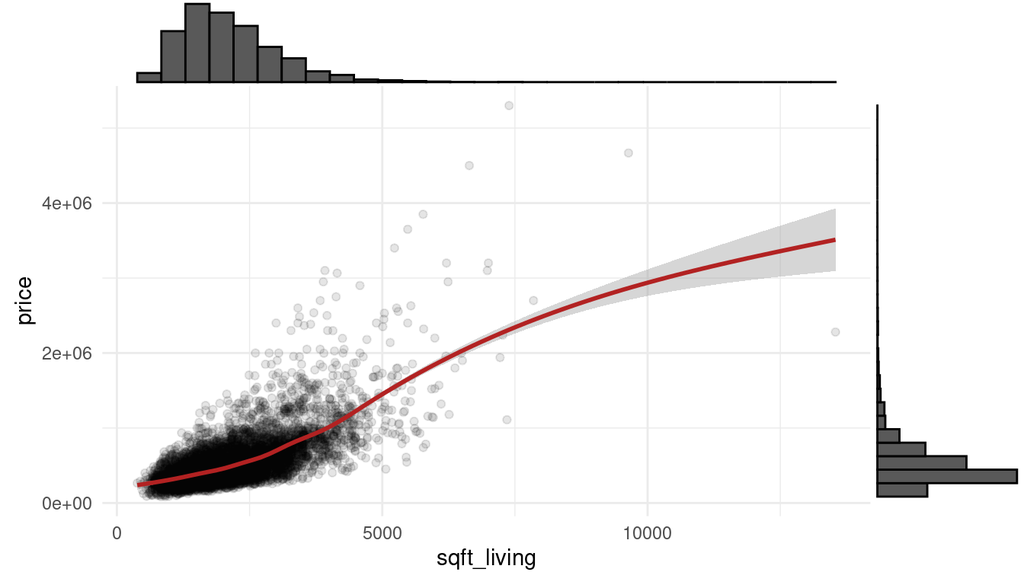

```r
library('ggExtra')
p <- ggplot(houses, aes(x=sqft_living, y=price)) +
  geom_point(alpha=.1) +
  geom_smooth(colour='firebrick')

ggMarginal(p, type = 'histogram')
```

> Both variables are right skewed. When we draw the scatterplot, the data is grouped into certain intervals, and the rest is sprinkled all around. In other words, for low price and sqft_living values, the data is condensed around the line (variance is low) but for the higher values the data covers a wider range around the line (variance is high). This is known as heteroskedasticity and as you will see later when covering regressions, it is trouble.

We will show you how to obtain a normal looking dataset using transformations:

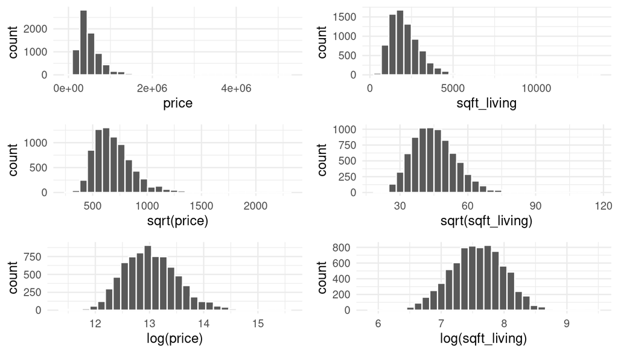

```r
library(gridExtra)
g1 <- ggplot(houses, aes(x=price)) +
  geom_histogram(colour='white')
g2 <- ggplot(houses, aes(x=sqrt(price))) +
  geom_histogram(colour='white')
g3 <- ggplot(houses, aes(x=log(price))) +
  geom_histogram(colour='white')

g4 <- ggplot(houses, aes(x=sqft_living)) +
  geom_histogram(colour='white')
g5 <- ggplot(houses, aes(x=sqrt(sqft_living))) +
  geom_histogram(colour='white')
g6 <- ggplot(houses, aes(x=log(sqft_living))) +
  geom_histogram(colour='white')

grid.arrange(g1,g4,g2,g5,g3,g6)
```

> price and sqft_living are originally right skewed. The sqrt transformation doesn’t make it symmetric but the log-transformed one is pretty much symmetric.

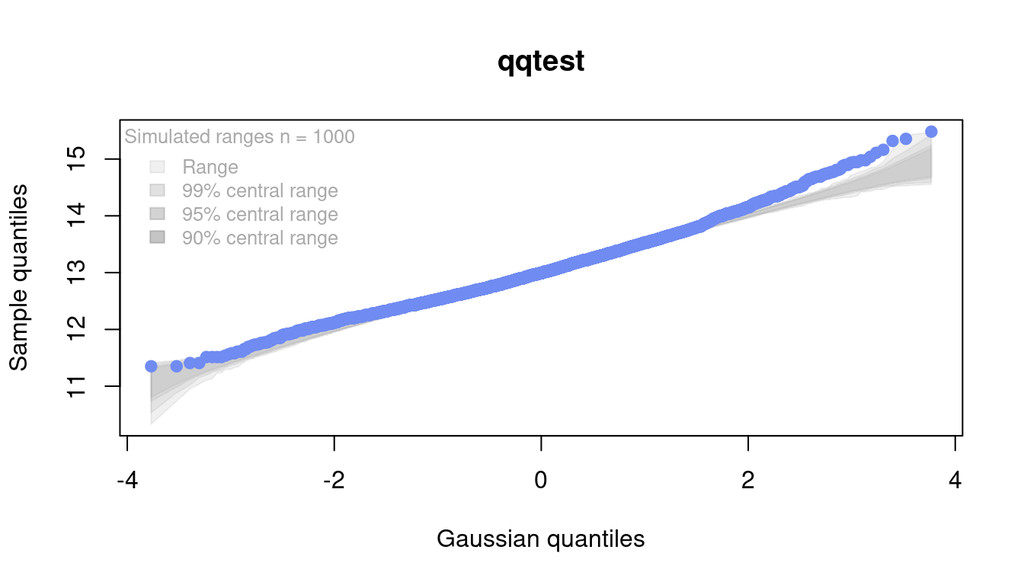

```r
library('qqtest')
qqtest(log(houses$price))
```

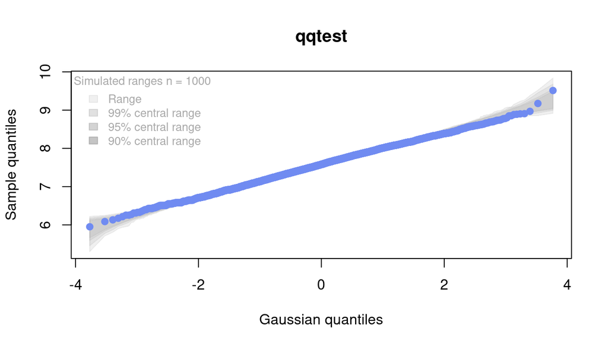

```r
qqtest(log(houses$sqft_living))
```

> The log transformation for sqft_living worked fine. qqtest shows it is in the envelope, so we cannot reject it is normal. But for price data we need more work. The edges are still out of the band.

## Parametric Transformations

A transformation function can generalize the transformations by sqrt and log functions:

$$T(x,\alpha) = \frac{x^\alpha-1}{\alpha}$$

It can be defined in R as:

```r
tform <- function(x, alpha){
  if(alpha == 0) {log(x)} else {(x^alpha-1)/alpha}
}
```

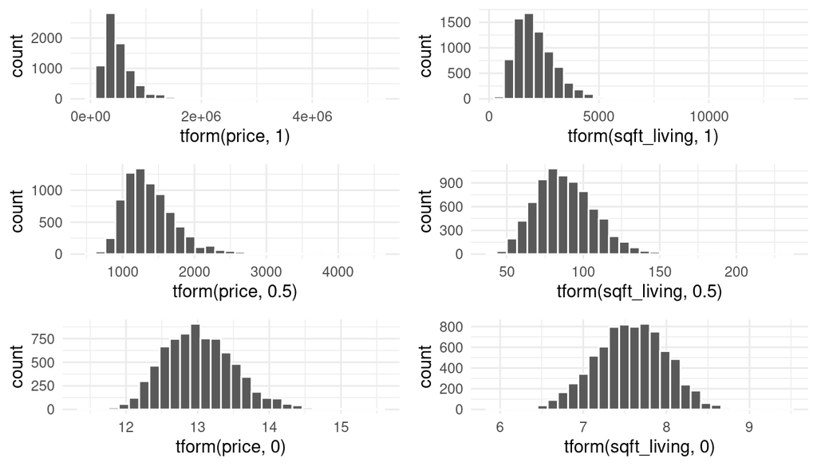

```r
g1 <- ggplot(houses, aes(x=tform(price,1))) +
  geom_histogram(colour='white')
g2 <- ggplot(houses, aes(x=tform(price,0.5))) +
  geom_histogram(colour='white')
g3 <- ggplot(houses, aes(x=tform(price,0))) +
  geom_histogram(colour='white')

g4 <- ggplot(houses, aes(x=tform(sqft_living,1))) +
  geom_histogram(colour='white')
g5 <- ggplot(houses, aes(x=tform(sqft_living,.5))) +
  geom_histogram(colour='white')
g6 <- ggplot(houses, aes(x=tform(sqft_living,0))) +
  geom_histogram(colour='white')

grid.arrange(g1,g4,g2,g5,g3,g6)
```

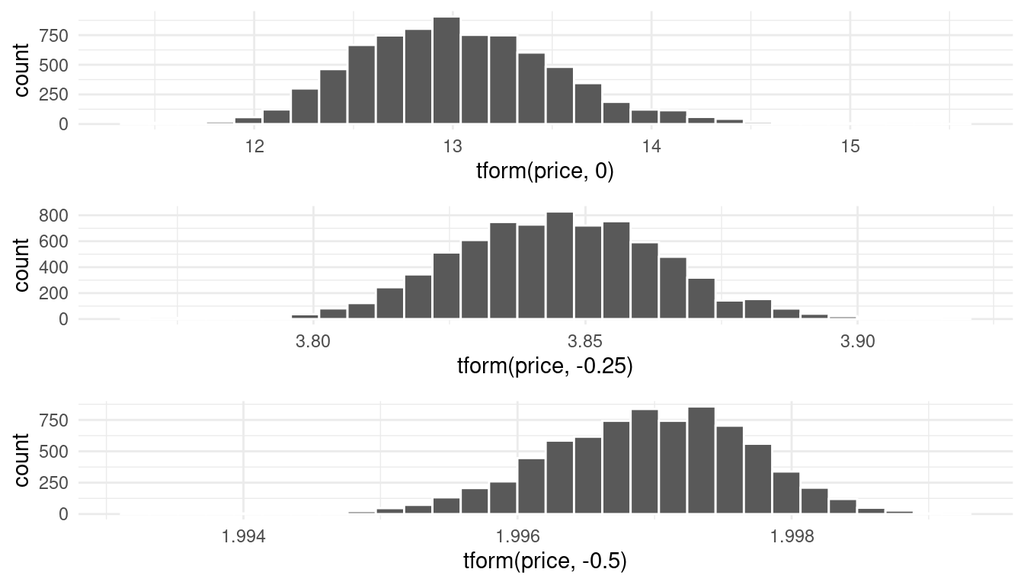

```r
g1 <- ggplot(houses, aes(x=tform(price,0))) +
  geom_histogram(colour='white')
g2 <- ggplot(houses, aes(x=tform(price,-0.25))) +
  geom_histogram(colour='white')
g3 <- ggplot(houses, aes(x=tform(price,-.5))) +
  geom_histogram(colour='white')

grid.arrange(g1,g2,g3)
```

> We reached the sweet spot when alpha = -0.25.

Let’s verify if it is normal enough:

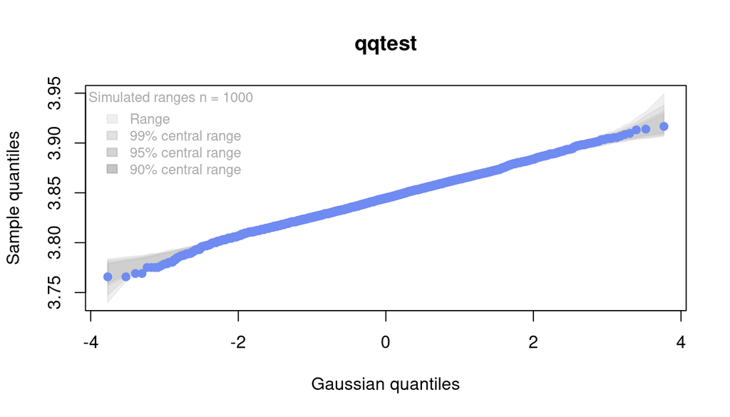

```r
qqtest(tform(houses$price,-0.25))
```

> The line is not perfectly linear, but it is in the band. So it is hard to reject it is not normal.

After the transformation, the relation is easier to model:

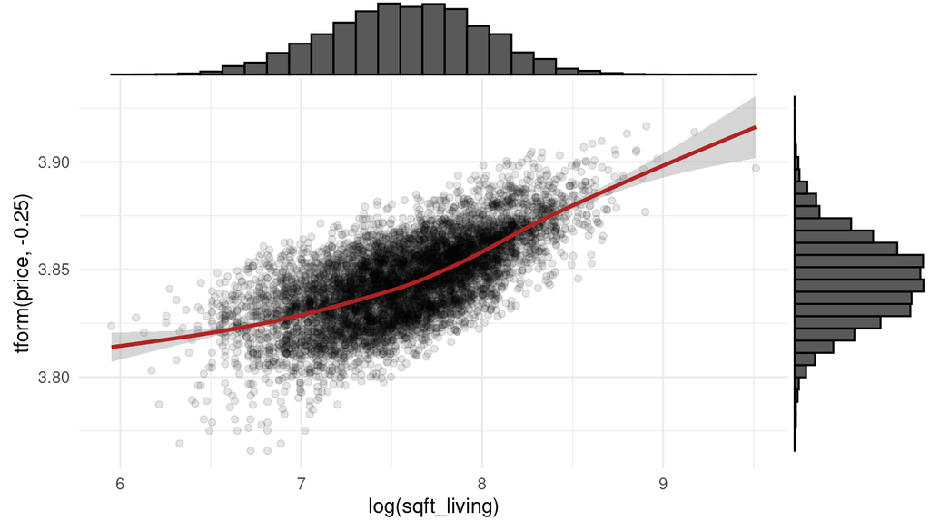

```r
p <- ggplot(houses, aes(x=log(sqft_living), y=tform(price,-.25))) +
  geom_point(alpha=.1) +
  geom_smooth(colour='firebrick')

ggMarginal(p, type = 'histogram')
```

> The plot is now better, we can see the relation smoother than the previous case. The spreaded points are now gathered around the line

# Sampling

In statistics, the central limit theorem suggests for any random variable $X$:

$$Z \sim \frac{\bar X_i - \mu}{\sigma/\sqrt n}$$

The above also implies the following:

$$\bar X_i \sim N(\mu,\sigma^2/n)$$

Let’s do it with sqft_living, price and bedrooms. All non-normal and one of them is discrete.

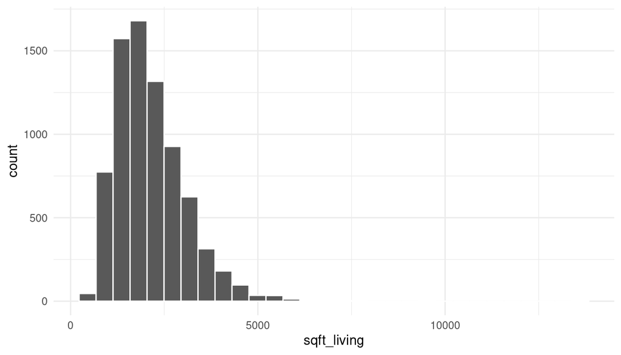

```r
ggplot(houses, aes(x=sqft_living)) +
  geom_histogram(colour='white')
```

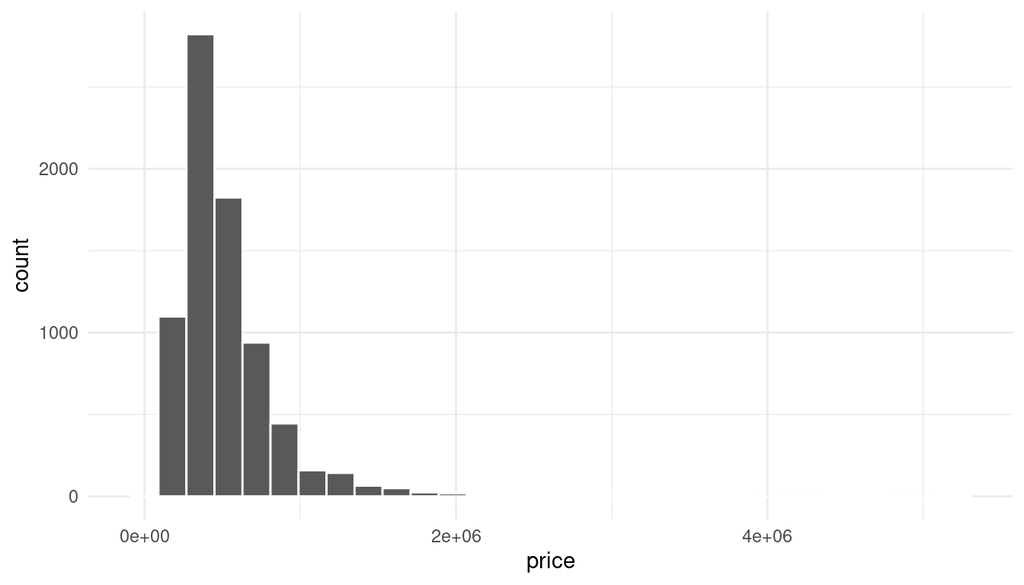

```r
ggplot(houses, aes(x=price)) +
  geom_histogram(colour='white')
```

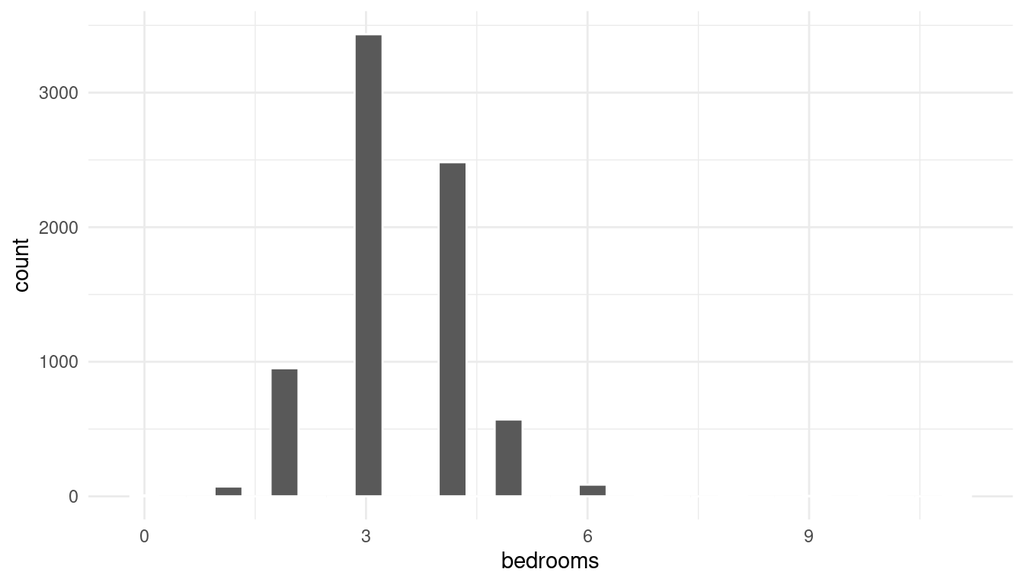

```r
ggplot(houses, aes(x=bedrooms)) +
  geom_histogram(colour='white')
```

Now let’s take random samples and calculate their averages following the below procedure:

- First, we will randomly select 200 rows from the data and repeat it 300 times,
- and choose the data in these rows for each 300 groups,
- then we will average the numbers fall in these rows, which will yield 300 averages, i.e. $X_i$ for $i \in [1,300]$:

```r
# 1. sample(1:nrow(houses), 100)
# 2. houses$price[sample(1:nrow(houses), 100)]
# 3. mean(houses$price[sample(1:nrow(houses), 100)])

set.seed(156)

Xbars <- sapply(1:300, function(i) mean(houses$sqft_living[sample(1:nrow(houses), 200)]))
Xbars <- data.frame(1:length(Xbars), Xbars)
colnames(Xbars) <- c('GroupID', 'Xbar')
Xbars
```

```
##     GroupID     Xbar
## 1         1 2124.990
## 2         2 2208.355
## 3         3 2127.170
## 4         4 2181.255
## 5         5 2183.965
## 6         6 2220.575
## 7         7 2043.690
## 8         8 2194.340
## 9         9 2117.680
## 10       10 2091.930
## 11       11 2088.275
## 12       12 2246.820
## 13       13 2093.300
## 14       14 2046.950
```

[output cut: 286 more lines]

```r
# houses %>% subset(group == 1)
```

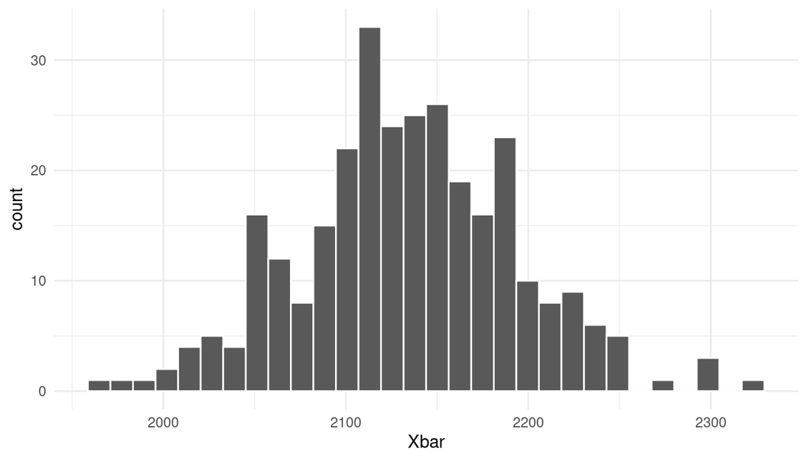

```r
ggplot(Xbars, aes(x=Xbar)) +
  geom_histogram(colour='white')
```

> It looks normal.

But is it?

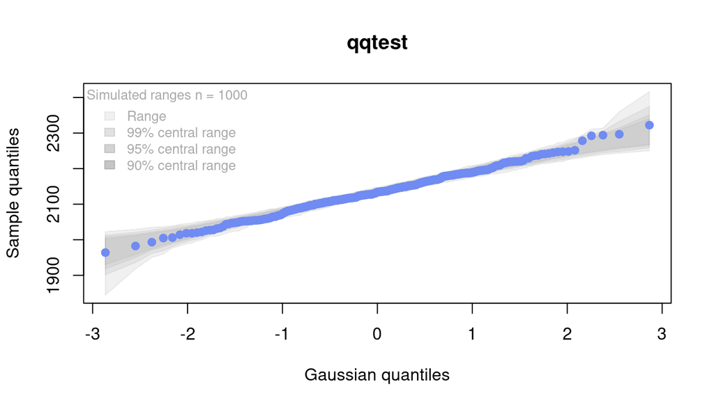

```r
qqtest(Xbars$Xbar)
```

> Magic!

Let’s do the magic with the prices data:

```r
set.seed(156)
Xbars <- sapply(1:300, function(i) mean(houses$price[sample(1:nrow(houses), 200)]))
Xbars <- data.frame(1:length(Xbars), Xbars)
colnames(Xbars) <- c('GroupID', 'Xbar')
Xbars
```

```
##     GroupID     Xbar
## 1         1 502801.7
## 2         2 547490.2
## 3         3 509000.5
## 4         4 521012.0
## 5         5 512178.5
## 6         6 543746.4
## 7         7 513831.7
## 8         8 606152.4
## 9         9 516952.6
## 10       10 534044.1
## 11       11 514045.9
## 12       12 539646.1
## 13       13 513090.0
## 14       14 480108.8
```

[output cut: 286 more lines]

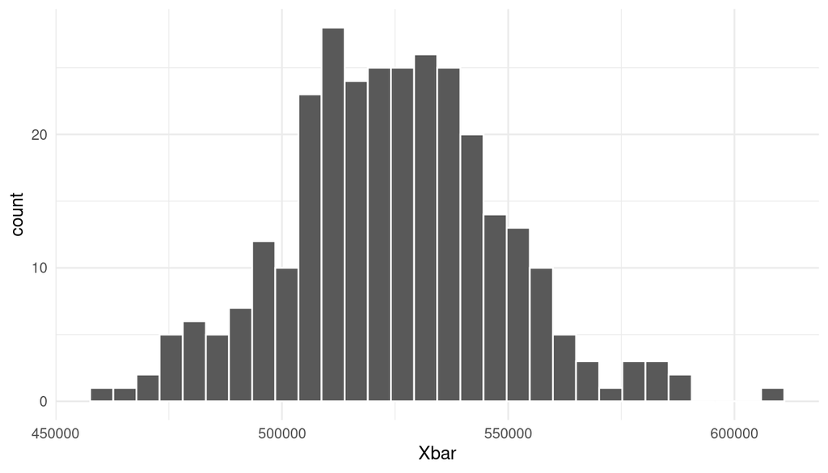

```r
ggplot(Xbars, aes(x=Xbar)) +
  geom_histogram(colour='white')
```

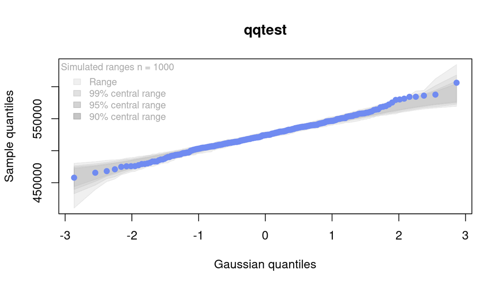

```r
qqtest(Xbars$Xbar)
```

> Magic!

What about # bedrooms? It is discrete, but normal is continuous.

```r
set.seed(156)
Xbars <- sapply(1:300, function(i) mean(houses$bedrooms[sample(1:nrow(houses), 200)]))
Xbars <- data.frame(1:length(Xbars), Xbars)
colnames(Xbars) <- c('GroupID', 'Xbar')
Xbars
```

```
##     GroupID  Xbar
## 1         1 3.355
## 2         2 3.390
## 3         3 3.300
## 4         4 3.300
## 5         5 3.385
## 6         6 3.365
## 7         7 3.245
## 8         8 3.390
## 9         9 3.375
## 10       10 3.340
## 11       11 3.345
## 12       12 3.455
## 13       13 3.370
## 14       14 3.305
```

[output cut: 286 more lines]

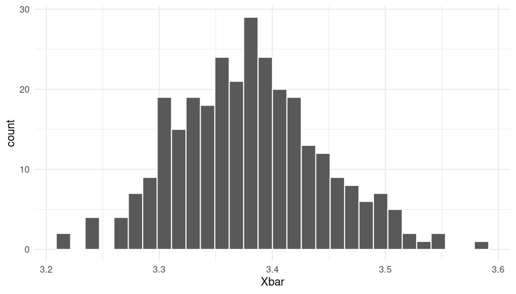

```r
ggplot(Xbars, aes(x=Xbar)) +
  geom_histogram(colour='white')
```

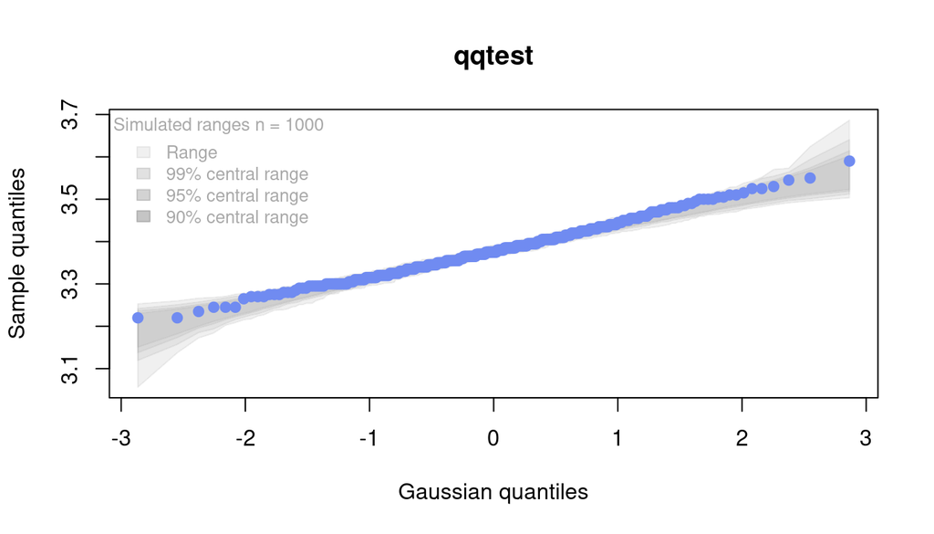

```r
qqtest(Xbars$Xbar)
```

> Magic!

# Deliverables

### 1. CLT

Choose a continuous or discrete numeric variable and check whether CLT holds:

- Plot the histogram of the variable, check its distribution. Know what you are playing with.
- if there are a lot of 0’s, remove them
- apply the above procedure. Here I picked 300 which was totally arbitrary. I averaged 200 numbers each times because the larger it is the better it is.
- Apply the above procedures, plot the histogram of $\bar X$’s and use qqtest function to test whether the distribution of $\bar X$’s is normal.
- Tell whether the magic works; according to qqtest is it normal or not.